# Minería de texto en preguntas abiertas

Felipe González Évora

31 de agosto de 2020

## Librerías utilizadas:

```r
suppressMessages(library(haven)) # Leer archivo SPSS
suppressMessages(library(hunspell)) # Corrector de ortografía
suppressMessages(library(dplyr)) # Manipulación de datos
suppressMessages(library(stringr)) # Manipulación de texto
suppressMessages(library(tm)) # Limpieza y transformación de texto
suppressMessages(library(ggplot2))
suppressMessages(library(wordcloud))
suppressMessages(library(tidytext))
suppressMessages(library(tidyr))
suppressMessages(library(widyr)) # Para hacer red de correlaciones
suppressMessages(library(igraph)) # Para plotear las redes
suppressMessages(library(ggraph))
suppressMessages(library(randomForest))
```

# Funciones para preprocesamiento de texto

## Corrección de ortografía

Descargar diccionario en español. Es necesario para las funciones del corrector de ortografía **hunspell**.

```r
dict.esp <- dictionary("es_ES")
```

```r
corrector.ortografia <- function(datos_texto, diccionario)
  {

  datos_corregidos <- data.frame(texto = datos_texto)
  datos_corregidos$texto <- as.character(datos_corregidos$texto)
  datos_corregidos$nuevo <- 0

    for (i in 1:dim(datos_corregidos)[1])
      {

      respuesta <- datos_corregidos[i,"texto"]
      incorrectas <- hunspell(respuesta, dict = diccionario) # Detectar palabras incorrectas
      buenas <- NULL

        if(length(unlist(incorrectas)) > 0)
          {

          for (k in 1:length(incorrectas[[1]]))
            {
              ## hunspell_suggest retorna una lista con un vector de posibles palabras para hacer la corrección
              buenas.sugeridas <- hunspell_suggest(incorrectas[[1]][k], dict = diccionario)
              buenas[k] <- buenas.sugeridas[[1]][1] ## La primera es por lo general la más probable.
            }

       names(buenas) <- unlist(incorrectas)
       datos_corregidos$nuevo[i] <- str_replace_all(respuesta, buenas)

          }
            else
                {

                 datos_corregidos$nuevo[i] <- datos_corregidos[i,"texto"]

                }

      }

    return(datos_corregidos)

 }
```

*Ejemplos:*

```r
corrector.ortografia("informacion baliosa", dict.esp)
```

```
##                 texto               nuevo
## 1 informacion baliosa información valiosa
```

```r
corrector.ortografia("peligrozo es vonito", dict.esp)
```

```
##                 texto               nuevo
## 1 peligrozo es vonito peligroso es bonito
```

## Lematización de texto

```r
corrector.lematizador <- function(datos_corregidos, diccionario)
  {

  datos_corregidos$nuevo <- as.character(datos_corregidos$nuevo)
  datos_corregidos$nuevo_stem <- 0

    for (i in 1:dim(datos_corregidos)[1])
      {

      respuesta <- datos_corregidos[i,"nuevo"]
      palabras <- hunspell_parse(respuesta, format = "latex") ## Parsear el texto
      proveniente <- hunspell_stem(unlist(palabras), dict = diccionario) ## Retorna una lista con la raíz  de cada palabra

      texto <- NULL

         if(length(unlist(proveniente)) > 0)
           {

           for (j in 1:length(proveniente))
             {

             palabra <- proveniente[[j]][1]
             texto <- paste(texto, palabra, sep = " ")
             }

          datos_corregidos$nuevo_stem[i] <- texto
           }
            else
              {

          datos_corregidos$nuevo_stem[i] <- respuesta

              }

       }

    return(datos_corregidos)
}
```

*Ejemplo:*

```r
corrector.lematizador(data.frame(nuevo="faltan e ignoran"), dict.esp)
```

```
##              nuevo        nuevo_stem
## 1 faltan e ignoran  faltar e ignorar
```

```r
corrector.lematizador(data.frame(nuevo="trámites"), dict.esp)
```

```
##      nuevo nuevo_stem
## 1 trámites    trámite
```

### **Leyendo datos:**

Los datos provienen de la **Encuesta Nacional de Percepción sobre la Transparencia del 2019**, realizada por la Contraloría General de la República. La pregunta abierta que se analiza en este documento pertenece al modulo de Participación Ciudadana. La pregunta es la siguiente:

## P1. ¿Qué le ha impedido participar de los asuntos del sector público?

```r
Data.C3 <- read_sav("datos-part-ciud.sav")

texto <- Data.C3 %>% select(F1_AB, F1_COD)
```

```r
texto$F1_COD <- as.character(texto$F1_COD)

texto <- texto %>%
            filter(F1_COD != "99" & F1_COD != "999")
```

```r
texto %>% head()
```

```
## # A tibble: 6 x 2
##   F1_AB                                                                   F1_COD
##   <chr>                                                                   <chr>
## 1 desconocimiento                                                         2
## 2 no se entera mucho de esto                                              5
## 3 Casi siempre a los que llaman son los mismos y son los que toman las d~ 88
## 4 Ser funcionaria pública                                                 88
## 5 No ha mucha información.                                                2
## 6 FALTA DE INFORMACIÓN                                                    2
```

# Preprocesamiento de texto

### Corrección de ortografía

```r
texto.resp <- texto %>% select(F1_AB)

texto.resp <- corrector.ortografia(texto.resp$F1_AB, dict.esp)

texto.resp[613, ]
```

```
##                    texto                nuevo
## 613 FALTA DE INFORMACION FALTA DE INFORMACIÓN
```

### Lematización del texto

```r
texto.resp <- corrector.lematizador(texto.resp, dict.esp)

texto.resp %>% select(nuevo, nuevo_stem) %>% head(3)
```

```
##                                                                              nuevo
## 1                                                                  desconocimiento
## 2                                                       no se entera mucho de esto
## 3 Casi siempre a los que llaman son los mismos y son los que toman las decisiones.
##                                                                      nuevo_stem
## 1                                                                    desconocer
## 2                                                    no se entera mucho de esto
## 3  casi siempre a los que llamar son los mismo y son los que toman las decisión
```

#### **Paquete tm:** Se usa para la limpieza y transformación del texto.

```r
limpiar.texto <- function(datos)
  {

  ## Transformar el texto a corpus
  corpus <- VCorpus(VectorSource(datos$nuevo_stem))

  ## Remover los números
  corpus <- tm_map(corpus, removeNumbers)

  ## Eliminar signos de puntuación
  corpus <- tm_map(corpus, removePunctuation)

  ## Convertir a minúscula
  corpus <- tm_map(corpus, content_transformer(tolower))

  ## Eliminar espacios en blanco de más
  corpus <- tm_map(corpus, stripWhitespace)

  ## Establecer palabras vacías:
  my_stopwords <- setdiff(stopwords("spanish"), c("también", "tampoco"))

  ## Eliminar palabras vacías
  corpus <- tm_map(corpus, removeWords, my_stopwords)

  corpus <- tm_map(corpus, stemDocument, language="spanish")

  return(corpus)

}
```

```r
corpus <- limpiar.texto(texto.resp)
```

La función devuelve un corpus:

```r
corpus
```

```
## <<VCorpus>>
## Metadata:  corpus specific: 0, document level (indexed): 0
## Content:  documents: 919
```

Obtener respuesta en la fila 4:

```r
corpus[[4]][1]
```

```
## $content
## [1] "ser funcionario pública"
```

# Análisis exploratorio

## Frecuencia de palabras:

Primero se crea una *matriz palabra-documento*. En esta matriz cada fila representa una palabra y cada columna una respuesta o documento.

```r
tdm <- as.matrix(
                 TermDocumentMatrix(corpus)
                )

head(tdm[ , 1:20], 5)
```

```
##            Docs
## Terms       1 2 3 4 5 6 7 8 9 10 11 12 13 14 15 16 17 18 19 20
##   abierto   0 0 0 0 0 0 0 0 0  0  0  0  0  0  0  0  0  0  0  0
##   académico 0 0 0 0 0 0 0 0 0  0  0  0  0  0  0  0  0  0  0  0
##   acced     0 0 0 0 0 0 0 0 0  0  0  0  0  0  0  0  0  0  0  0
##   acces     0 0 0 0 0 0 0 0 0  0  0  0  0  0  0  0  0  0  0  0
##   acceso    0 0 0 0 0 0 0 0 0  0  0  0  0  0  0  0  0  0  0  0
```

#### Gráfico de frecuencia de palabras

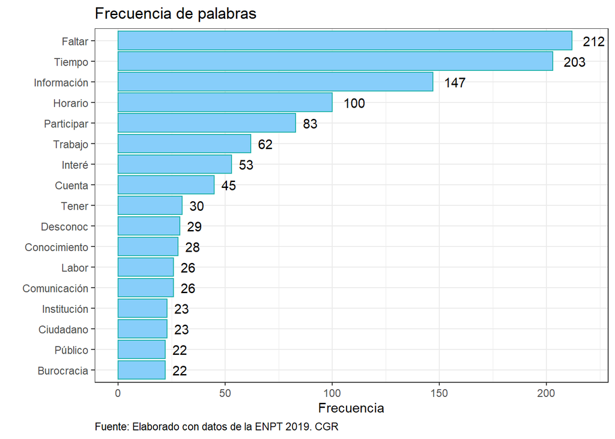

```r
## Obtener frecuencia de cada palabra
frecuencia <- sort(rowSums(as.matrix(tdm)), decreasing = TRUE)
datos <- data.frame(palabras = names(frecuencia), conteo = frecuencia)

## Lo siguiente es para que la primera letra de cada palabra quede en mayúscula:
datos$palabras <- str_to_title(datos$palabras)

datos %>%
    filter(conteo > 21) %>%
      ggplot(aes(reorder(palabras, conteo), conteo)) +
        geom_bar(stat = "identity", fill = "#87CEFA", colour = "#20B2AA") +
        geom_text(aes(label = conteo), hjust = -0.5) +
        coord_flip(ylim = c(0, max(datos$conteo)+6)) +
        theme_bw() +
        labs(y = "Frecuencia",
           x = " ",
          title = "Frecuencia de palabras",
          caption = "Fuente: Elaborado con datos de la ENPT 2019. CGR") +
        theme(plot.caption = element_text(hjust = 0))
```

## Nube de palabras

La nube de palabras es una representación visual de las palabras distintivas que conforman un texto. El tamaño de las palabras específicas depende del porcentaje de apariciones en el texto.

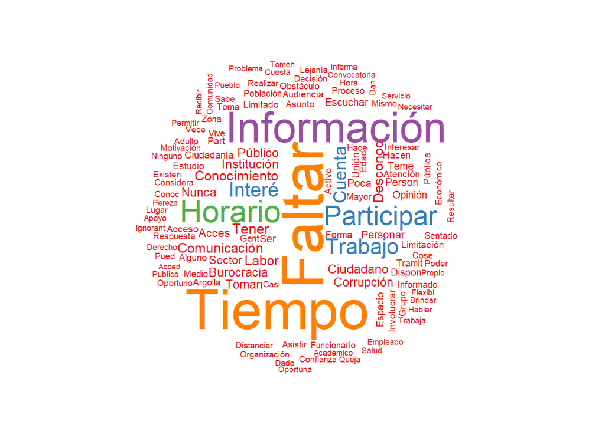

```r
wordcloud(words = datos$palabras,
         freq = datos$conteo,
         min.freq = 1,
         max.words = 120,
         random.order = FALSE,
         colors = brewer.pal(5, "Set1"))
```

## Frecuencia de palabras con bigramas:

Un N-grama es una subsecuencia de n elementos de una secuencia de texto dada.

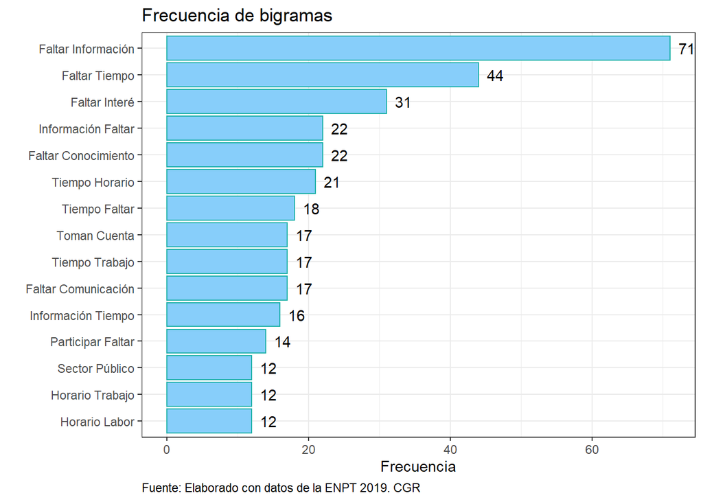

```r
## Corpus to dataframe:

texto.df <- data.frame(respuesta = sapply(corpus,
                                          as.character),
                       stringsAsFactors = F)

## Utilizando tidytext para formar los bigramas:
bigramas <-
  texto.df %>%
      unnest_tokens(bigram, respuesta,
                    token = "ngrams",
                    n = 2)  %>%
      count(bigram,
            sort = TRUE)

bigramas.10 <- bigramas %>%
                filter(n > 10) ## Frecuencia mayor a 10


bigramas.10$bigram <- str_to_title(bigramas.10$bigram)


bigramas.10 %>%
      ggplot(aes(reorder(bigram, n), n)) +
      geom_bar(stat = "identity", fill = "#87CEFA", colour = "#20B2AA") +
      geom_text(aes(label = n), hjust = -0.5) +
      coord_flip() +
      theme_bw() +
      labs(y = "Frecuencia",
           x = " ",
           title = "Frecuencia de bigramas",
           caption = "Fuente: Elaborado con datos de la ENPT 2019. CGR") +
      theme(plot.caption = element_text(hjust = 0))
```

## Nube de bigramas

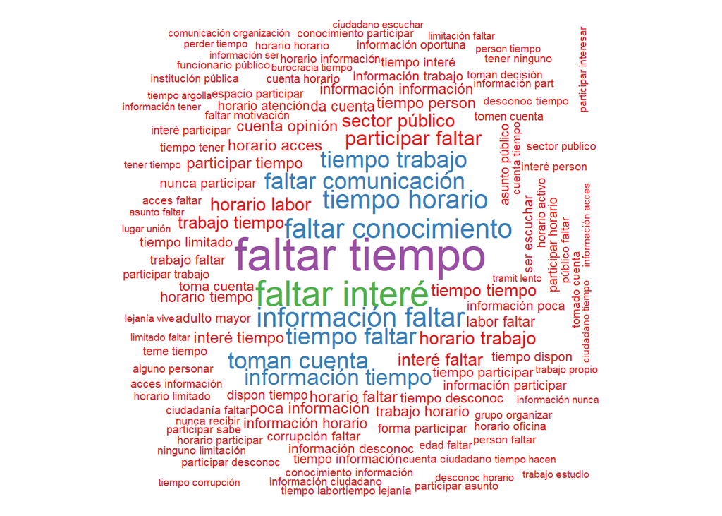

```r
wordcloud(words = bigramas$bigram,
         freq = bigramas$n,
         min.freq = 1,
         max.words = 120,
         random.order = FALSE,
         colors = brewer.pal(5, "Set1"))
```

## Red de correlaciones

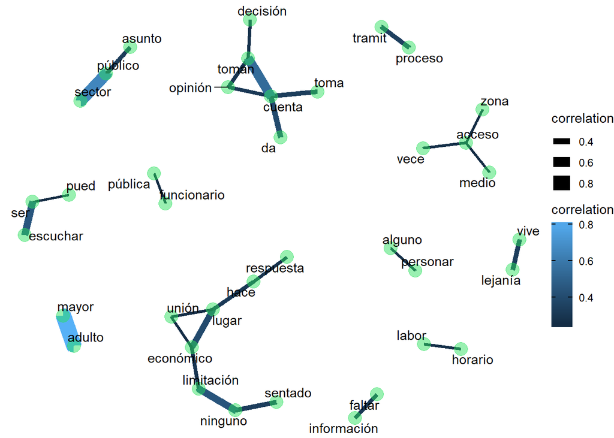

```r
word_cors <- texto.df %>%
                      mutate(section = row_number()) %>%
                      unnest_tokens(word, respuesta,
                                    token = "ngrams",
                                    n = 1)  %>%
                      group_by(word) %>%
                      filter(n() >= 5) %>%
                      widyr::pairwise_cor(word, section,
                                   sort = TRUE)

word_cors %>%
  filter(correlation >= .24) %>%
  graph_from_data_frame() %>%
  ggraph(layout = "fr") +
  geom_edge_link(aes(#edge_alpha = correlation,
                     edge_width = correlation,
                     colour = correlation)) +
  geom_node_point(color = "#29e05d7a", size = 5) +
  geom_node_text(aes(label = name), repel = TRUE) +
  theme_void()
```

# **Clasificación de texto**

Una vez el texto está limpio, se procede a crear la matriz *documento-palabra* en la que cada fila corresponde a una observación o documento (respuesta). Las columnas, por su parte, representan las palabras contenidas en todas las respuestas. Dentro de esta matriz, se encuentra la frecuencia de las palabras que se mencionan en los documentos.

```r
tdm <- data.frame(as.matrix(
                            DocumentTermMatrix(corpus)))

head(tdm[ , 1:10], 15)
```

```
##    abierto académico acced acces acceso accionar aceptar acercar activa activo
## 1        0         0     0     0      0        0       0       0      0      0
## 2        0         0     0     0      0        0       0       0      0      0
## 3        0         0     0     0      0        0       0       0      0      0
## 4        0         0     0     0      0        0       0       0      0      0
## 5        0         0     0     0      0        0       0       0      0      0
## 6        0         0     0     0      0        0       0       0      0      0
## 7        0         0     0     0      0        0       0       0      0      0
## 8        0         0     0     0      0        0       0       0      0      0
## 9        0         0     0     0      0        0       0       0      0      0
## 10       0         0     0     0      0        0       0       0      0      0
## 11       0         0     0     0      0        0       0       0      0      0
## 12       0         0     0     0      0        0       0       0      0      0
## 13       0         0     0     0      0        0       0       0      0      0
## 14       0         0     0     0      0        0       0       0      0      1
## 15       0         0     0     0      0        0       0       0      0      0
```

Agregar variable a predecir

```r
tdm$respuesta <- texto$F1_COD

tdm %>%
  group_by(respuesta) %>%
  summarise(Frecuencia = n()) %>%
  arrange(desc(Frecuencia))
```

```
## # A tibble: 21 x 2
##    respuesta Frecuencia
##    <chr>          <int>
##  1 1                218
##  2 2                195
##  3 3                 68
##  4 4                 67
##  5 5                 58
##  6 19                57
##  7 88                45
##  8 6                 44
##  9 7                 34
## 10 8                 27
## # ... with 11 more rows
```

## Selección de palabras

Se estima individualmente para cada palabra el estadístico Chi-cuadrado con respecto a las clases, por lo que se analiza la dependencia entre la palabra y las clases

```r
chi.cuadrado <- function(datos, umbral, respuesta = "var_respuesta")
  {

   num.col <- NULL
     for (k in 1:dim(datos)[2])
       {

         #datos[ , k] <- as.numeric(unlist(datos[ , k]))

         chi <- chisq.test(table(datos[ , respuesta], datos[ , k]),
                           simulate.p.value = TRUE)

            if(chi$p.value >= umbral)
              {

              num.col[k] <- k

              }
       }

    datos[ , as.vector(na.omit(num.col))] <- NULL

    print(paste("El total de palabras que quedan como predictoras después de eliminar las que tiene un p-value mayor a", umbral, "son",
                dim(datos)[2]-1), sep = ",")

    return(datos)

 }
```

```r
tdm.chi <- chi.cuadrado(tdm, 0.8, "respuesta")
```

```
## [1] "El total de palabras que quedan como predictoras después de eliminar las que tiene un p-value mayor a 0.8 son 532"
```

## Dividiendo los datos en entrenamiento y testing

```r
set.seed(12345678)

muestra <- sample(1:nrow(tdm), size = floor(nrow(tdm)*0.80))

entrenamiento.todo <- tdm[muestra , ]
test.todo <- tdm[-muestra , ]

entrenamiento.chi <- tdm.chi[muestra , ]
test.chi <- tdm.chi[-muestra , ]
```

## Modelo con todas las palabras

```r
entrenamiento.todo$respuesta <- as.factor(entrenamiento.todo$respuesta)

set.seed(1234)

modRF = randomForest(respuesta ~ .,
                 data = entrenamiento.todo,
                 ntree = 200,
                 replace = TRUE,
                 type = "classification")

predictionRF <- predict(modRF, test.todo)

niveles <- levels(as.factor(tdm$respuesta))

MC <- table(factor(test.todo$respuesta, levels = niveles, ordered = TRUE),
                   factor(predictionRF, levels = niveles, ordered = TRUE))
```

### *Precisión:*

```r
precision.todo <- sum(diag(MC)) / sum(MC)

paste("La precisión utilizando",
      dim(entrenamiento.todo)[2], "variables es de",
      scales::percent(precision.todo, accuracy = 0.1))
```

```
## [1] "La precisión utilizando 597 variables es de 79.3%"
```

## Modelo con todas las palabras seleccionadas

```r
entrenamiento.chi$respuesta <- as.factor(entrenamiento.chi$respuesta)


set.seed(1234)

modRF = randomForest(respuesta ~ .,
                 data = entrenamiento.chi,
                 ntree = 200,
                 replace = TRUE,
                 type = "classification")

predictionRF <- predict(modRF, test.chi)

MC <- table(factor(test.chi$respuesta, levels = niveles, ordered = TRUE),
                   factor(predictionRF, levels = niveles, ordered = TRUE))
```

### *Precisión:*

```r
precision.chi <- sum(diag(MC)) / sum(MC)

paste("La precisión utilizando",
      dim(entrenamiento.chi)[2], "variables es de",
      scales::percent(precision.chi, accuracy = 0.1))
```

```
## [1] "La precisión utilizando 533 variables es de 81.0%"
```

### Matriz de confusión:

```r
MC
```

```
##
##       1 10 11 12 13 14 15 16 17 18 19  2 20  3  4  5  6  7  8 88  9
##   1  39  0  0  0  0  0  0  0  0  0  0  1  0  1  0  0  0  0  0  3  0
##   10  0  1  0  0  0  0  0  0  0  0  0  0  0  0  0  0  0  0  0  0  0
##   11  0  0  3  0  0  0  0  0  0  0  0  0  0  0  0  0  0  0  0  0  0
##   12  0  0  0  0  0  0  0  0  0  0  0  0  0  0  0  0  0  0  0  0  0
##   13  0  0  0  0  0  0  0  0  0  0  1  0  0  0  0  0  1  0  0  0  0
##   14  0  0  0  0  0  1  0  0  0  0  0  0  0  0  0  0  0  0  0  1  0
##   15  0  0  0  0  0  0  0  0  0  0  0  0  0  0  0  0  0  0  0  0  0
##   16  0  0  0  0  0  0  0  0  0  0  0  0  0  0  0  0  0  0  0  0  0
##   17  0  0  0  0  0  0  0  0  0  0  0  0  0  0  0  0  0  0  0  1  0
##   18  1  0  0  0  0  0  0  0  0  1  0  0  0  0  0  0  0  0  0  0  0
##   19  0  0  0  0  0  0  0  0  0  0 10  0  1  0  0  0  0  0  0  1  0
##   2   1  0  0  0  0  0  0  0  0  0  0 34  0  0  0  0  1  0  1  0  0
##   20  0  0  0  0  0  0  0  0  0  0  0  0  1  0  0  0  0  0  0  0  0
##   3   0  0  0  0  0  0  0  0  0  0  0  1  0 18  0  0  0  0  0  0  0
##   4   0  0  0  0  0  0  0  0  0  0  0  2  0  0 14  0  1  0  0  3  0
##   5   2  0  0  0  0  0  0  0  0  0  0  0  0  0  0  3  3  0  0  1  0
##   6   0  0  0  0  0  0  0  0  0  0  0  1  0  0  0  0  8  0  0  0  0
##   7   1  0  0  0  0  0  0  0  0  0  0  0  0  1  0  0  0  5  0  0  1
##   8   0  0  0  0  0  0  0  0  0  0  0  0  0  0  0  0  0  0  3  1  0
##   88  0  0  0  0  0  0  0  0  0  0  0  1  0  0  0  0  1  0  0  6  0
##   9   0  0  0  0  0  0  0  0  0  0  0  0  0  0  0  0  0  0  0  0  2
```

## *Resultado de predicción de respuestas:*

El siguiente cuadro muestra la comparación entre la distribución porcentual de las categorías codificadas manualmente y las predichas por los bosques aleatorios.

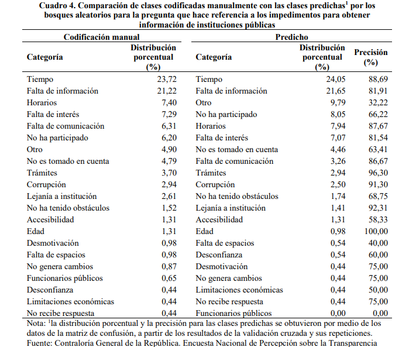